# Regression Anlaysis of ’mtcars

Radha

22 November 2015

## Introduction :

As an exployee for Motor Trend, a magazine about the automobile industry, I analysed the ‘mtcars’ dataset (a data set 32 cars across 11 measures, captured between 1974-1975), to explore the relationship between a set of variables and miles per gallon (MPG) (outcome). I have tried to answer the following two questions: 1. “Is an automatic or manual transmission better for MPG” 2. “Quantify the MPG difference between automatic and manual transmissions”

## Executive Summary :

Following are the findings from the analysis: . The impact of manual vs. automatic transmission on MPG is statistically significant.

. Manual Transmission cars tend to have higher MPG than Automatic Transmission ones.

. However, as the car weight increases, with every 1000lb increase in weight, MPG for manual transmission cars falls faster than that for automatic transmission cars (all other factors remaining constant).

. Qsec (which indicates how fast car is driven) also impacts MPG in a significant way.

## Analysis and Data Processing

First, the library “datasets” was loaded, and then “mtcars” dataset was copied into another variable cars_data. Next, correlation between variables was checked (results shown in Table 1) and the following was observed. This could potentially help when adding / removing variables to the regression model:

- MPG seemed to be highly negatively correlated with Cyl, Disp, HP and WT
- Cyl seemed to be highly correlated with Disp, HP, WT and VS (negatively) To check the high-level impact of transmission type, a box plot was drawn (Figure
1. It indicated that the impact is significant visually. But the same was tested for statistical significance too (assuming normal distribution and IID), using a Welch 2-sample T-test. A p-value of 0.0013 indicated that the different in impact was > 0 at least 95% times.

On closer analysis, it would be proved that the result obtained about was merely a start. A regression analysis between mpg (outcome) and am (variable) would give R-square of 0.36 only. Which means there is scope for addition of more variable, as well as for interaction between few variables. Hence, more models were chosen. Following code snippet demonstrates the logic used when selecting / Rejecting models:

```
##
## Call:
## lm(formula = mpg ~ am + cyl, data = cars_data)
##
## Residuals:
##     Min      1Q  Median      3Q     Max
## -5.6856 -1.7172 -0.2657  1.8838  6.8144
##
## Coefficients:
##             Estimate Std. Error t value Pr(>|t|)
## (Intercept)  34.5224     2.6032  13.262 7.69e-14 ***
## am            2.5670     1.2914   1.988   0.0564 .
## cyl          -2.5010     0.3608  -6.931 1.28e-07 ***
## ---
## Signif. codes:  0 '***' 0.001 '**' 0.01 '*' 0.05 '.' 0.1 ' ' 1
##
## Residual standard error: 3.059 on 29 degrees of freedom
## Multiple R-squared:  0.759,  Adjusted R-squared:  0.7424
## F-statistic: 45.67 on 2 and 29 DF,  p-value: 1.094e-09
```

```
##
## Call:
## lm(formula = mpg ~ am + disp, data = cars_data)
##
## Residuals:
##     Min      1Q  Median      3Q     Max
## -4.6382 -2.4751 -0.5631  2.2333  6.8386
##
## Coefficients:
##              Estimate Std. Error t value Pr(>|t|)
## (Intercept) 27.848081   1.834071  15.184 2.45e-15 ***
## am           1.833458   1.436100   1.277    0.212
## disp        -0.036851   0.005782  -6.373 5.75e-07 ***
## ---
## Signif. codes:  0 '***' 0.001 '**' 0.01 '*' 0.05 '.' 0.1 ' ' 1
##
## Residual standard error: 3.218 on 29 degrees of freedom
## Multiple R-squared:  0.7333, Adjusted R-squared:  0.7149
## F-statistic: 39.87 on 2 and 29 DF,  p-value: 4.749e-09
```

```
##
## Call:
## lm(formula = mpg ~ am + hp, data = cars_data)
##
## Residuals:
##     Min      1Q  Median      3Q     Max
## -4.3843 -2.2642  0.1366  1.6968  5.8657
##
## Coefficients:
##              Estimate Std. Error t value Pr(>|t|)
## (Intercept) 26.584914   1.425094  18.655  < 2e-16 ***
## am           5.277085   1.079541   4.888 3.46e-05 ***
## hp          -0.058888   0.007857  -7.495 2.92e-08 ***
## ---
## Signif. codes:  0 '***' 0.001 '**' 0.01 '*' 0.05 '.' 0.1 ' ' 1
##
## Residual standard error: 2.909 on 29 degrees of freedom
## Multiple R-squared:  0.782,  Adjusted R-squared:  0.767
## F-statistic: 52.02 on 2 and 29 DF,  p-value: 2.55e-10
```

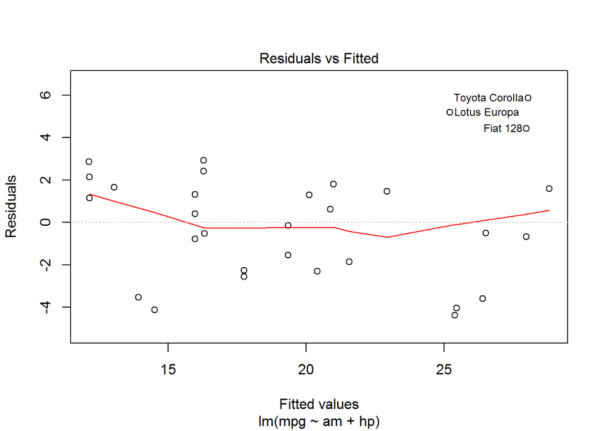

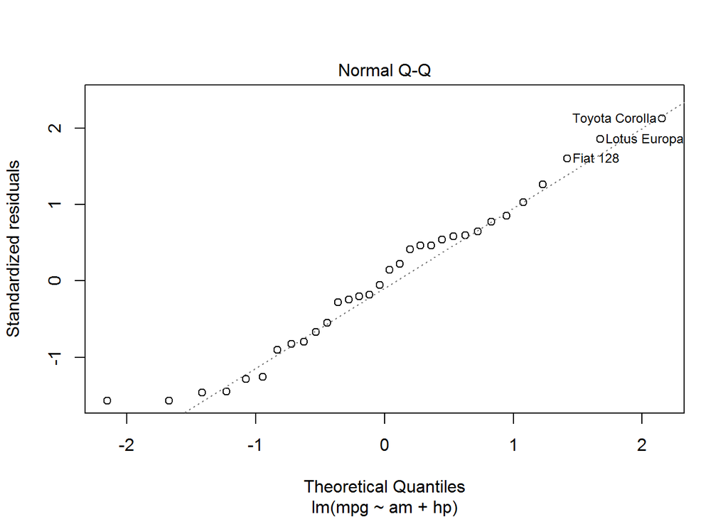

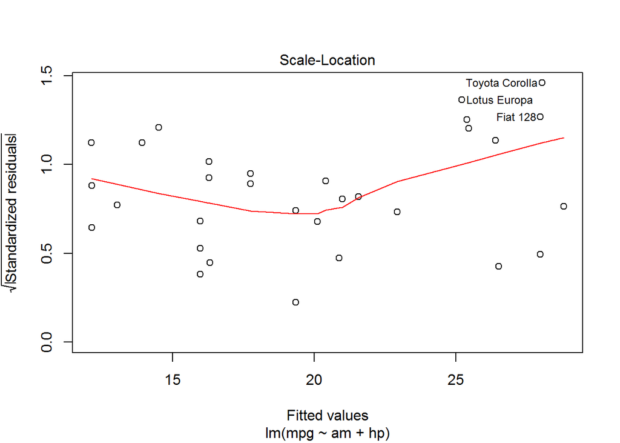

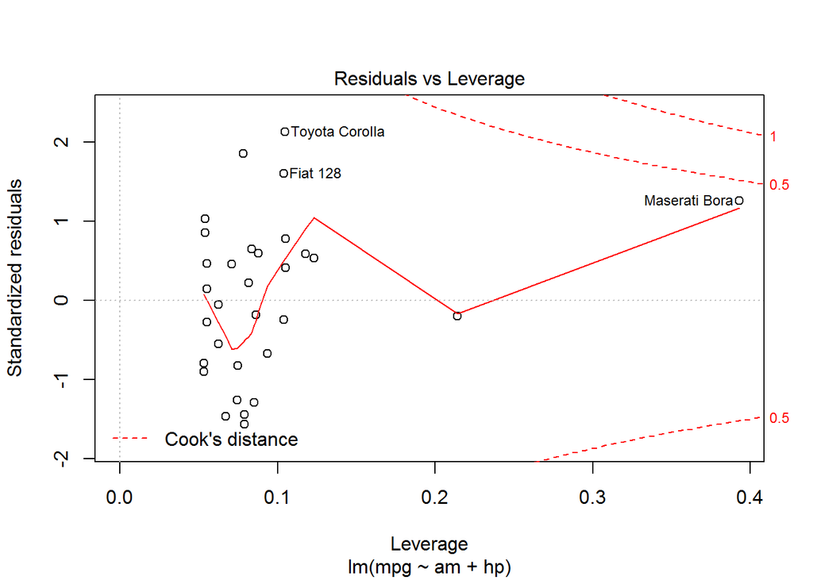

```
##
## Call:
## lm(formula = mpg ~ am + hp + drat, data = cars_data)
##
## Residuals:
##     Min      1Q  Median      3Q     Max
## -4.0797 -1.6355 -0.2626  1.7048  5.8111
##
## Coefficients:
##              Estimate Std. Error t value Pr(>|t|)
## (Intercept) 19.665041   5.687565   3.458  0.00176 **
## am           3.974658   1.489316   2.669  0.01252 *
## hp          -0.054562   0.008508  -6.413 6.07e-07 ***
## drat         1.894724   1.508615   1.256  0.21952
## ---
## Signif. codes:  0 '***' 0.001 '**' 0.01 '*' 0.05 '.' 0.1 ' ' 1
##
## Residual standard error: 2.881 on 28 degrees of freedom
## Multiple R-squared:  0.7937, Adjusted R-squared:  0.7716
## F-statistic:  35.9 on 3 and 28 DF,  p-value: 9.877e-10
```

```
##
## Call:
## lm(formula = mpg ~ am + hp + qsec, data = cars_data)
##
## Residuals:
##     Min      1Q  Median      3Q     Max
## -4.4560 -1.6704  0.2195  1.6448  5.5397
##
## Coefficients:
##             Estimate Std. Error t value Pr(>|t|)
## (Intercept) 16.63207   11.16842   1.489 0.147612
## am           5.98311    1.33813   4.471 0.000117 ***
## hp          -0.04912    0.01343  -3.659 0.001040 **
## qsec         0.46130    0.51338   0.899 0.376552
## ---
## Signif. codes:  0 '***' 0.001 '**' 0.01 '*' 0.05 '.' 0.1 ' ' 1
##
## Residual standard error: 2.919 on 28 degrees of freedom
## Multiple R-squared:  0.7881, Adjusted R-squared:  0.7654
## F-statistic: 34.72 on 3 and 28 DF,  p-value: 1.424e-09
```

```
##
## Call:
## lm(formula = mpg ~ am + hp + vs, data = cars_data)
##
## Residuals:
##     Min      1Q  Median      3Q     Max
## -5.0175 -1.7433  0.1203  1.4900  5.5150
##
## Coefficients:
##             Estimate Std. Error t value Pr(>|t|)
## (Intercept) 23.33420    2.23293  10.450 3.61e-11 ***
## am           5.29854    1.03757   5.107 2.07e-05 ***
## hp          -0.04472    0.01078  -4.150 0.000281 ***
## vs           2.65885    1.44247   1.843 0.075901 .
## ---
## Signif. codes:  0 '***' 0.001 '**' 0.01 '*' 0.05 '.' 0.1 ' ' 1
##
## Residual standard error: 2.796 on 28 degrees of freedom
## Multiple R-squared:  0.8056, Adjusted R-squared:  0.7848
## F-statistic: 38.68 on 3 and 28 DF,  p-value: 4.31e-10
```

```
##
## Call:
## lm(formula = mpg ~ am + hp + gear, data = cars_data)
##
## Residuals:
##    Min     1Q Median     3Q    Max
## -3.975 -2.357  0.105  1.953  6.237
##
## Coefficients:
##              Estimate Std. Error t value Pr(>|t|)
## (Intercept) 23.186368   3.898969   5.947 2.11e-06 ***
## am           3.956119   1.777326   2.226   0.0342 *
## hp          -0.059737   0.007925  -7.537 3.28e-08 ***
## gear         1.100938   1.175271   0.937   0.3569
## ---
## Signif. codes:  0 '***' 0.001 '**' 0.01 '*' 0.05 '.' 0.1 ' ' 1
##
## Residual standard error: 2.915 on 28 degrees of freedom
## Multiple R-squared:  0.7887, Adjusted R-squared:  0.766
## F-statistic: 34.83 on 3 and 28 DF,  p-value: 1.377e-09
```

```
##
## Call:
## lm(formula = mpg ~ am + hp + carb, data = cars_data)
##
## Residuals:
##     Min      1Q  Median      3Q     Max
## -4.5177 -2.6847  0.2868  1.9040  5.3248
##
## Coefficients:
##             Estimate Std. Error t value Pr(>|t|)
## (Intercept) 26.34511    1.41173  18.662  < 2e-16 ***
## am           5.88019    1.14459   5.137 1.91e-05 ***
## hp          -0.04491    0.01257  -3.573   0.0013 **
## carb        -0.73074    0.51838  -1.410   0.1697
## ---
## Signif. codes:  0 '***' 0.001 '**' 0.01 '*' 0.05 '.' 0.1 ' ' 1
##
## Residual standard error: 2.861 on 28 degrees of freedom
## Multiple R-squared:  0.7965, Adjusted R-squared:  0.7747
## F-statistic: 36.53 on 3 and 28 DF,  p-value: 8.16e-10
```

```
##
## Call:
## lm(formula = mpg ~ am + hp + wt, data = cars_data)
##
## Residuals:
##     Min      1Q  Median      3Q     Max
## -3.4221 -1.7924 -0.3788  1.2249  5.5317
##
## Coefficients:
##              Estimate Std. Error t value Pr(>|t|)
## (Intercept) 34.002875   2.642659  12.867 2.82e-13 ***
## am           2.083710   1.376420   1.514 0.141268
## hp          -0.037479   0.009605  -3.902 0.000546 ***
## wt          -2.878575   0.904971  -3.181 0.003574 **
## ---
## Signif. codes:  0 '***' 0.001 '**' 0.01 '*' 0.05 '.' 0.1 ' ' 1
##
## Residual standard error: 2.538 on 28 degrees of freedom
## Multiple R-squared:  0.8399, Adjusted R-squared:  0.8227
## F-statistic: 48.96 on 3 and 28 DF,  p-value: 2.908e-11
```

```
##
## Call:
## lm(formula = mpg ~ am + wt, data = cars_data)
##
## Residuals:
##     Min      1Q  Median      3Q     Max
## -4.5295 -2.3619 -0.1317  1.4025  6.8782
##
## Coefficients:
##             Estimate Std. Error t value Pr(>|t|)
## (Intercept) 37.32155    3.05464  12.218 5.84e-13 ***
## am          -0.02362    1.54565  -0.015    0.988
## wt          -5.35281    0.78824  -6.791 1.87e-07 ***
## ---
## Signif. codes:  0 '***' 0.001 '**' 0.01 '*' 0.05 '.' 0.1 ' ' 1
##
## Residual standard error: 3.098 on 29 degrees of freedom
## Multiple R-squared:  0.7528, Adjusted R-squared:  0.7358
## F-statistic: 44.17 on 2 and 29 DF,  p-value: 1.579e-09
```

The model, which made sense was the one with high R2, AM as a significant variable, homoscedasticity, and no variable insignificant. Since none of the variable combinations chosen had helped, interaction variables were introduced. Interaction between AM and WT seemed to be interesting, a seen from regression analysis, as well as by plotting on a graph.

```
##
## Call:
## lm(formula = mpg ~ am * wt, data = cars_data)
##
## Residuals:
##     Min      1Q  Median      3Q     Max
## -3.6004 -1.5446 -0.5325  0.9012  6.0909
##
## Coefficients:
##             Estimate Std. Error t value Pr(>|t|)
## (Intercept)  31.4161     3.0201  10.402 4.00e-11 ***
## am           14.8784     4.2640   3.489  0.00162 **
## wt           -3.7859     0.7856  -4.819 4.55e-05 ***
## am:wt        -5.2984     1.4447  -3.667  0.00102 **
## ---
## Signif. codes:  0 '***' 0.001 '**' 0.01 '*' 0.05 '.' 0.1 ' ' 1
##
## Residual standard error: 2.591 on 28 degrees of freedom
## Multiple R-squared:  0.833,  Adjusted R-squared:  0.8151
## F-statistic: 46.57 on 3 and 28 DF,  p-value: 5.209e-11
```

```
##
## Call:
## lm(formula = mpg ~ wt * am, data = cars_data)
##
## Residuals:
##     Min      1Q  Median      3Q     Max
## -3.6004 -1.5446 -0.5325  0.9012  6.0909
##
## Coefficients:
##             Estimate Std. Error t value Pr(>|t|)
## (Intercept)  31.4161     3.0201  10.402 4.00e-11 ***
## wt           -3.7859     0.7856  -4.819 4.55e-05 ***
## am           14.8784     4.2640   3.489  0.00162 **
## wt:am        -5.2984     1.4447  -3.667  0.00102 **
## ---
## Signif. codes:  0 '***' 0.001 '**' 0.01 '*' 0.05 '.' 0.1 ' ' 1
##
## Residual standard error: 2.591 on 28 degrees of freedom
## Multiple R-squared:  0.833,  Adjusted R-squared:  0.8151
## F-statistic: 46.57 on 3 and 28 DF,  p-value: 5.209e-11
```

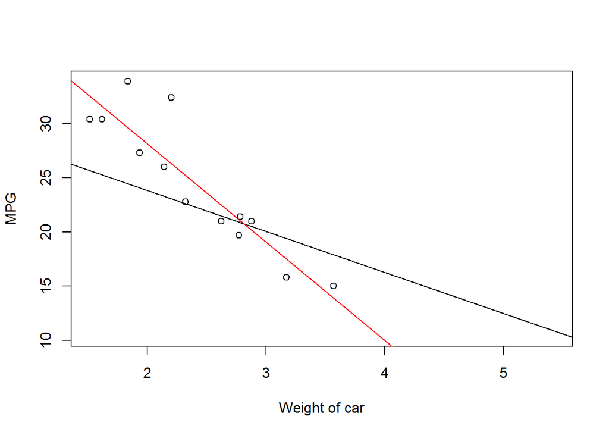

To see, if any other variable improved the R2, without compromising on the variable significance or homoscedasticity, multiple models were chosen. The results are as follows:

```
##
## Call:
## lm(formula = mpg ~ am * wt + cyl, data = cars_data)
##
## Residuals:
##     Min      1Q  Median      3Q     Max
## -3.4621 -1.4913 -0.7879  1.3959  5.3499
##
## Coefficients:
##             Estimate Std. Error t value Pr(>|t|)
## (Intercept)  34.2830     2.7965  12.259 1.52e-12 ***
## am           11.9385     3.8453   3.105  0.00444 **
## wt           -2.3689     0.8244  -2.874  0.00782 **
## cyl          -1.1814     0.3803  -3.106  0.00442 **
## am:wt        -4.1974     1.3115  -3.200  0.00350 **
## ---
## Signif. codes:  0 '***' 0.001 '**' 0.01 '*' 0.05 '.' 0.1 ' ' 1
##
## Residual standard error: 2.265 on 27 degrees of freedom
## Multiple R-squared:  0.877,  Adjusted R-squared:  0.8588
## F-statistic: 48.13 on 4 and 27 DF,  p-value: 6.643e-12
```

```
##
## Call:
## lm(formula = mpg ~ am * wt + disp, data = cars_data)
##
## Residuals:
##     Min      1Q  Median      3Q     Max
## -2.8556 -1.6062 -0.7542  1.6198  5.3870
##
## Coefficients:
##             Estimate Std. Error t value Pr(>|t|)
## (Intercept) 28.83107    3.02619   9.527 3.97e-10 ***
## am          15.01017    3.96925   3.782 0.000786 ***
## wt          -1.74592    1.14758  -1.521 0.139789
## disp        -0.01758    0.00762  -2.307 0.028987 *
## am:wt       -5.27454    1.34472  -3.922 0.000543 ***
## ---
## Signif. codes:  0 '***' 0.001 '**' 0.01 '*' 0.05 '.' 0.1 ' ' 1
##
## Residual standard error: 2.412 on 27 degrees of freedom
## Multiple R-squared:  0.8605, Adjusted R-squared:  0.8399
## F-statistic: 41.64 on 4 and 27 DF,  p-value: 3.563e-11
```

```
##
## Call:
## lm(formula = mpg ~ am * wt + hp, data = cars_data)
##
## Residuals:
##     Min      1Q  Median      3Q     Max
## -3.0639 -1.3315 -0.9347  1.2180  5.0822
##
## Coefficients:
##              Estimate Std. Error t value Pr(>|t|)
## (Intercept) 30.947333   2.723411  11.363 8.55e-12 ***
## am          11.554813   4.023277   2.872  0.00784 **
## wt          -2.515586   0.844497  -2.979  0.00605 **
## hp          -0.026949   0.009796  -2.751  0.01048 *
## am:wt       -3.577910   1.442796  -2.480  0.01968 *
## ---
## Signif. codes:  0 '***' 0.001 '**' 0.01 '*' 0.05 '.' 0.1 ' ' 1
##
## Residual standard error: 2.332 on 27 degrees of freedom
## Multiple R-squared:  0.8696, Adjusted R-squared:  0.8503
## F-statistic: 45.01 on 4 and 27 DF,  p-value: 1.451e-11
```

```
##
## Call:
## lm(formula = mpg ~ am * wt + drat, data = cars_data)
##
## Residuals:
##     Min      1Q  Median      3Q     Max
## -4.1982 -1.4632 -0.6669  0.9714  6.1346
##
## Coefficients:
##             Estimate Std. Error t value Pr(>|t|)
## (Intercept)  25.9354     6.3628   4.076 0.000362 ***
## am           13.9149     4.3793   3.177 0.003703 **
## wt           -3.5119     0.8346  -4.208 0.000255 ***
## drat          1.3535     1.3827   0.979 0.336349
## am:wt        -5.1731     1.4514  -3.564 0.001385 **
## ---
## Signif. codes:  0 '***' 0.001 '**' 0.01 '*' 0.05 '.' 0.1 ' ' 1
##
## Residual standard error: 2.593 on 27 degrees of freedom
## Multiple R-squared:  0.8388, Adjusted R-squared:  0.8149
## F-statistic: 35.11 on 4 and 27 DF,  p-value: 2.464e-10
```

```
##
## Call:
## lm(formula = mpg ~ am * wt + qsec, data = cars_data)
##
## Residuals:
##     Min      1Q  Median      3Q     Max
## -3.5076 -1.3801 -0.5588  1.0630  4.3684
##
## Coefficients:
##             Estimate Std. Error t value Pr(>|t|)
## (Intercept)    9.723      5.899   1.648 0.110893
## am            14.079      3.435   4.099 0.000341 ***
## wt            -2.937      0.666  -4.409 0.000149 ***
## qsec           1.017      0.252   4.035 0.000403 ***
## am:wt         -4.141      1.197  -3.460 0.001809 **
## ---
## Signif. codes:  0 '***' 0.001 '**' 0.01 '*' 0.05 '.' 0.1 ' ' 1
##
## Residual standard error: 2.084 on 27 degrees of freedom
## Multiple R-squared:  0.8959, Adjusted R-squared:  0.8804
## F-statistic: 58.06 on 4 and 27 DF,  p-value: 7.168e-13
```

```
##
## Call:
## lm(formula = mpg ~ am * wt + vs, data = cars_data)
##
## Residuals:
##     Min      1Q  Median      3Q     Max
## -3.6148 -1.6820 -0.7623  1.2926  5.1013
##
## Coefficients:
##             Estimate Std. Error t value Pr(>|t|)
## (Intercept)  26.2539     3.3458   7.847 1.95e-08 ***
## am           14.3204     3.8658   3.704 0.000962 ***
## wt           -2.7026     0.8183  -3.303 0.002703 **
## vs            2.9297     1.0945   2.677 0.012487 *
## am:wt        -4.6634     1.3292  -3.508 0.001599 **
## ---
## Signif. codes:  0 '***' 0.001 '**' 0.01 '*' 0.05 '.' 0.1 ' ' 1
##
## Residual standard error: 2.346 on 27 degrees of freedom
## Multiple R-squared:  0.8681, Adjusted R-squared:  0.8485
## F-statistic: 44.41 on 4 and 27 DF,  p-value: 1.698e-11
```

```
##
## Call:
## lm(formula = mpg ~ am * wt + gear, data = cars_data)
##
## Residuals:
##     Min      1Q  Median      3Q     Max
## -3.4521 -1.7682 -0.4178  0.9777  6.3028
##
## Coefficients:
##             Estimate Std. Error t value Pr(>|t|)
## (Intercept)  28.9679     5.2368   5.532 7.33e-06 ***
## am           14.9125     4.3163   3.455 0.001834 **
## wt           -3.6775     0.8172  -4.500 0.000117 ***
## gear          0.6353     1.1034   0.576 0.569540
## am:wt        -5.5608     1.5317  -3.631 0.001166 **
## ---
## Signif. codes:  0 '***' 0.001 '**' 0.01 '*' 0.05 '.' 0.1 ' ' 1
##
## Residual standard error: 2.623 on 27 degrees of freedom
## Multiple R-squared:  0.8351, Adjusted R-squared:  0.8106
## F-statistic: 34.17 on 4 and 27 DF,  p-value: 3.333e-10
```

```
##
## Call:
## lm(formula = mpg ~ am * wt + carb, data = cars_data)
##
## Residuals:
##     Min      1Q  Median      3Q     Max
## -3.4928 -1.3574 -0.5405  1.4872  5.2298
##
## Coefficients:
##             Estimate Std. Error t value Pr(>|t|)
## (Intercept)  30.8833     2.9720  10.392 6.19e-11 ***
## am           13.0145     4.3429   2.997  0.00579 **
## wt           -3.1781     0.8652  -3.673  0.00104 **
## carb         -0.6423     0.4216  -1.523  0.13931
## am:wt        -4.1334     1.6056  -2.574  0.01585 *
## ---
## Signif. codes:  0 '***' 0.001 '**' 0.01 '*' 0.05 '.' 0.1 ' ' 1
##
## Residual standard error: 2.532 on 27 degrees of freedom
## Multiple R-squared:  0.8463, Adjusted R-squared:  0.8235
## F-statistic: 37.15 on 4 and 27 DF,  p-value: 1.307e-10
```

## Appendix

Table 1

```
##                    mpg cyl disp  hp drat    wt  qsec vs am gear carb
## Mazda RX4         21.0   6  160 110 3.90 2.620 16.46  0  1    4    4
## Mazda RX4 Wag     21.0   6  160 110 3.90 2.875 17.02  0  1    4    4
## Datsun 710        22.8   4  108  93 3.85 2.320 18.61  1  1    4    1
## Hornet 4 Drive    21.4   6  258 110 3.08 3.215 19.44  1  0    3    1
## Hornet Sportabout 18.7   8  360 175 3.15 3.440 17.02  0  0    3    2
## Valiant           18.1   6  225 105 2.76 3.460 20.22  1  0    3    1
```

```
##        mpg   cyl  disp    hp  drat    wt  qsec    vs    am  gear  carb
## mpg   1.00 -0.85 -0.85 -0.78  0.68 -0.87  0.42  0.66  0.60  0.48 -0.55
## cyl  -0.85  1.00  0.90  0.83 -0.70  0.78 -0.59 -0.81 -0.52 -0.49  0.53
## disp -0.85  0.90  1.00  0.79 -0.71  0.89 -0.43 -0.71 -0.59 -0.56  0.39
## hp   -0.78  0.83  0.79  1.00 -0.45  0.66 -0.71 -0.72 -0.24 -0.13  0.75
## drat  0.68 -0.70 -0.71 -0.45  1.00 -0.71  0.09  0.44  0.71  0.70 -0.09
## wt   -0.87  0.78  0.89  0.66 -0.71  1.00 -0.17 -0.55 -0.69 -0.58  0.43
## qsec  0.42 -0.59 -0.43 -0.71  0.09 -0.17  1.00  0.74 -0.23 -0.21 -0.66
## vs    0.66 -0.81 -0.71 -0.72  0.44 -0.55  0.74  1.00  0.17  0.21 -0.57
## am    0.60 -0.52 -0.59 -0.24  0.71 -0.69 -0.23  0.17  1.00  0.79  0.06
## gear  0.48 -0.49 -0.56 -0.13  0.70 -0.58 -0.21  0.21  0.79  1.00  0.27
## carb -0.55  0.53  0.39  0.75 -0.09  0.43 -0.66 -0.57  0.06  0.27  1.00
```

Figure 1

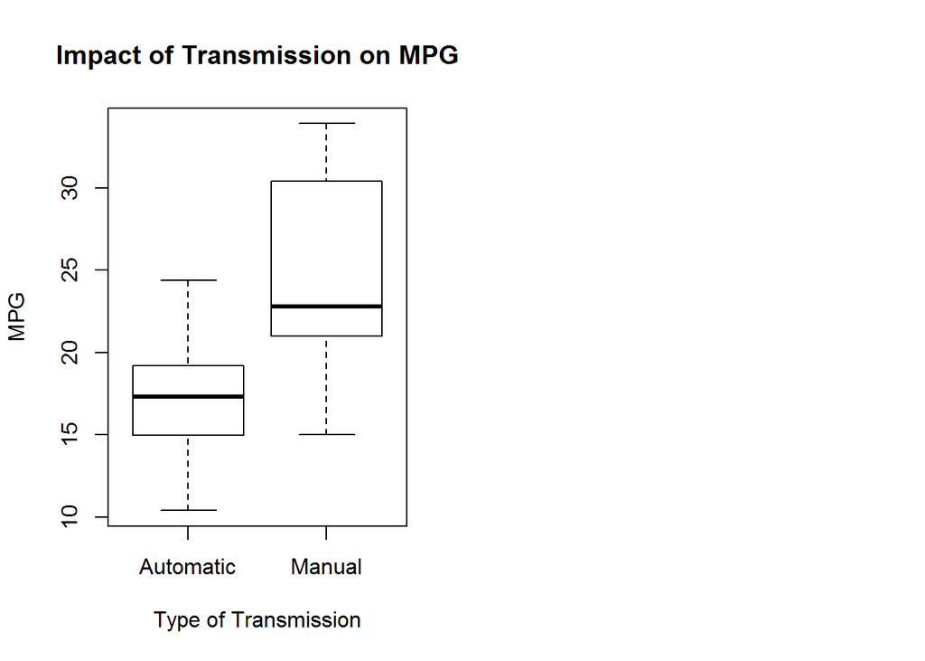

Table 2

```
##              Estimate Std. Error   t value     Pr(>|t|)
## (Intercept)  9.723053  5.8990407  1.648243 0.1108925394
## amManual    14.079428  3.4352512  4.098515 0.0003408693
## wt          -2.936531  0.6660253 -4.409038 0.0001488947
## qsec         1.016974  0.2520152  4.035366 0.0004030165
## amManual:wt -4.141376  1.1968119 -3.460340 0.0018085763
```

```
## [1] "R square:"
```

```
## [1] 0.8958514
```

Figure 2

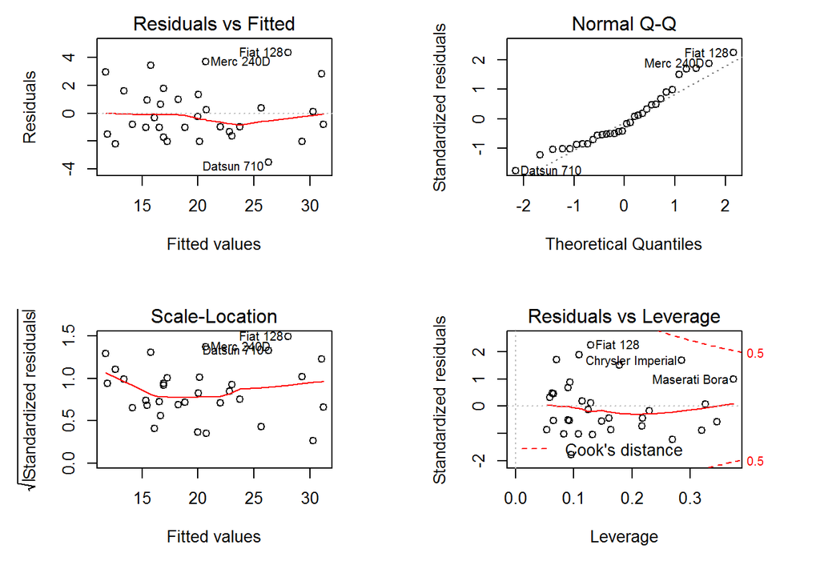

Table 3

```
## Analysis of Variance Table
##
## Model 1: mpg ~ am * wt + qsec
## Model 2: mpg ~ am + wt + qsec
##   Res.Df    RSS Df Sum of Sq      F   Pr(>F)
## 1     27 117.28
## 2     28 169.29 -1    -52.01 11.974 0.001809 **
## ---
## Signif. codes:  0 '***' 0.001 '**' 0.01 '*' 0.05 '.' 0.1 ' ' 1
```